# A hierarchical model of hotel property transactions

Thomas Loeber

July 10, 2018

## Initialization

Let’s start by clearing the workspace. Next, we load packages and saved models, and then import our data and create new variables. (For the most part, new variables were already created when cleaning the data in Python, the only exception are variables that should be of type “factor”, which is specific to R.)

```r
# clear the workspace
rm(list = ls())

# Load packages and set up Stan
library(rstan)
library(miscTools)
rstan_options(auto_write = TRUE)  #Save compiled model for faster re-estimation
options(mc.cores = parallel::detectCores())  #Enable using multiple cores

# # Load saved models
# for (file in (list.files(pattern = "*.RData"))) load(file)
# rm(file)  #remove temporary variable

# import data
data_train <- read.table("../data_raw/data_train_R.csv",
                         header = TRUE, sep = ",")
data_test <- read.table("../data_raw/data_test_R.csv",
                        header = TRUE, sep = ",",
                        stringsAsFactors = FALSE)

# Change all years in test set to 2016, because that's the most similar year
# we have data for.
data_test[, "year"] <- 2016

# Add a copy of year that we will convert to factor, because we will treat it
# as random effect
data_train$year_factor <- as.factor(data_train$year)
data_test$year_factor <- data_test$year

# # Concatenate all factors from both training and test set
factor_vars <- c("msa", "tract", "category", "saleaffiliation", "year_factor")
# data_all_factors <- rbind(data_train[, factor_vars],
#                           data_test[, factor_vars])
# # Convert each variable to a factor to get proper encoding
# for (v in factor_vars) {
#   data_all_factors[, v] <- as.factor(data_all_factors[, v])
# }

# Convert categorical variables to factor using encoding from combined training
# and test set.
for (v in factor_vars) {
  # Convert each variable in test set to factor using levels from training set
  data_test[, v] <- factor(data_test[, v],
                           levels = levels(data_train[, v]))
}

# See how many observations we lose by dropping categories with new levels
sum(complete.cases(data_test) == FALSE)
```

```
## [1] 32
```

```r
# We only lose 32 observation, so let's get rid of those
data_test <- data_test[complete.cases(data_test), ]
```

## Preprocessing

I already cleaned the data in a previous notebook, but one last step is to standardize all numeric independent variables and then put them in a list that we can pass to Stan.

As will become clearer below when I lay out the Stan code, the data need to come in a list containing all the variables used in the calculations. I thus define a function to which we pass the names of the dependent varible, independent variables, and random effects. The function then outputs a list containing all the necessary elements required by our Stan funciton. In addition, this function also allows us to standardize the numeric predictors. I follow Andrew Gelman’s recommendation to standardize the predictor by dividing by two standard deviations, rather than one, as is common in machine learning. The advantage is that this brings the standard deviation of numeric variables closer to the standard deviation of binary variables, which ranges from zero for unbalanced variables to 0.5 for balanced variables. In order to achieve this custom standardization, I define another function that can be called by the function assembling the data list.

```r
### Function to standardize predictors:
standardize <- function(df) {
  # standardizes continuous variables by dividing by 2 standard
  # deviations (in order to keep sd similar to binary inputs).
  #
  # Args:
  #   df: data frame or matrix with numeric inputs
  #
  # Returns:
  #   same data type as input (data frame or matrix), containing standardized
  #   variables, plus two vectors with means and standard deviations,
  #   respectively, of variables that were standardized.

  # Create new data frame or matrix, depending on input, to be returned
  df_2 <- df

  # Initialize vectors to save means and standard deviations of standardized variables (will remain NA for non-continuous variables)
  means <- rep(NA, ncol(df))
  std_dev <- rep(NA, ncol(df))
  names(means) <- colnames(df)
  names(std_dev) <- colnames(df)

  # Loop over all variables to standardize them, if appropriate
  n_features = dim(df)[2]
  for (feature in 1:n_features) {
    # test whether feature is a factor (if so, skip to the next feature):
    if (is.factor(df[, feature]))
      next

    # tests whether feature's range is 0-1; skip if so
    if ((min(df[, feature]) == 0) && (max(df[, feature]) == 1)) {

      # for computational efficiency, only test whether the feature only maps onto 2 values if we already made sure its minimum and
      # maximum are 0 and 1 respectively: If it's range does consist of only 2 values, skip to the next feature.
      if (length(table(df[, feature])) == 2)
        next
    }

    # Standardize Continuous features
    mu = mean(df[, feature])
    sigma = sd(df[, feature])
    df_2[, feature] <- (df[, feature] - mu)/(2 * sigma)

    # Save means and standard deviations.
    means[feature] <- mu
    std_dev[feature] <- sigma
  }

  return(list(data = df_2, means = means, std_dev = std_dev))
}

# S_1_1 <-standardize (X_1_1) summary (S_1_1)
```

```r
### Function to create vectorized Stan input
make_stan_data <- function(y, fe_formula, groups = NULL,       data, test_data, standardize_X = TRUE, standardize_y = FALSE) {
  # Creates a list in the right format to pass to Stan as data for estimating a
  # hierarchical model (convert factors to dummy variables). Missing values
  # need to be removed or imputed before data are passed to this function.
  # If the target variable is not standardized, it also returns its mean (mu_y)
  # and standard deviation (sd_y), which can be used to set an informative prior
  # for the intercept. If the features are standardized, it returns a vector of
  # their means and standard deviations to convert coefficients to original
  # scale.
  #
  # Args:
  #   y: character, containing name of target variable.
  #   fe_formula: character, containing the formula for the fixed effects.
  #   groups: character vector, with each element referencing a grouping
  #         variable of type factor. Default value: no groups.
  #   data: data.frame, containing all the variables referenced above.
  #         Factors will automatically be converted to integers using
  #         one-hot-encoding.
  #   standardize_X: boolean variable, denoting whether to standardize X.
  #         (Divides by 2 standard deviations to keep variance similar to
  #         binary variables, as long as those are not to unbalanced).
  #         Default: True.
  #   standardize_y: boolean variable, denoting whether to standardize y.
  #         (Divides by 2 standard deviations). Default: False.
  #
  # Returns:
  #   list, can be directly passed to stan() as the data argument


  # Check that none of the grouping variables for the random effects is also included in the fixed effects
  library(stringr)
  for (group in groups) {
    if (str_detect(fe_formula, group)) {
      # raise warning rather than error because the name of the grouping variable may simply appear as a substring of a different
      # variable.
      warning(paste(group, "may appear both as a fixed and random effect"))
    }
  }

  # Create model matrix (for automatic one-hot encoding of factors)
  model_formula <- as.formula(paste("~", fe_formula))
  mm <- model.matrix(model_formula, data = data)
  # mm_test <- model.matrix(model_formula, data = data_test)

  # Replace dots, if any, in variable names (necessary for Stan)
  for (i in 1:dim(mm)[2]) {
    colnames(mm)[i] <- str_replace_all(colnames(mm)[i], " ", "")
  }
  # Do the same for test data
  # colnames(mm_test) <- colnames(mm)

  # Extract X by deleting 1st column of ones
  X <- mm[, -1]
  # X_test <- mm_test[, -1]

  # Start a list with variables to be returned
  data_list = list(K = (ncol(mm) - 1),
                   N = nrow(mm))
                   # N_test = nrow(mm_test))

  # Standardize continuous variables in X, if requested, and add to data list
  if (standardize_X == TRUE) {
    X_standardized <- standardize(X)
    data_list$X <- X_standardized$data
    # data_list$X_test <- X_test # Must already be transformed
    data_list$mu_x <- X_standardized$means
    data_list$sd_x <- X_standardized$std_dev

    # Otherwise, just add X
    } else {
      data_list$X <- X
      # data_list$X_test <- X_test
    }

  # Add the target y (under its proper name)
  if (standardize_y == FALSE) {
    data_list[[y]] <- data[, y]  #Remember that y is a string
    data_list$mu_y <- mean(data[, y])
    data_list$sd_y <- sd(data[, y])

    # Standardize, if requested.  Note that this function only works on data frames, so we use drop = F to preserve the type data frame,
    # and then convert it to vector by subsetting
  } else {
    y_standardized <- standardize(data[, y, drop = FALSE])
    data_list[[y]] <- y_standardized$data[, 1]
    data_list$mu_y <- y_standardized$means
    data_list$sd_y <- y_standardized$std_dev
  }

  # if more than 1 group, store the number of groups
  if (length(groups) > 1) {
    data_list$n_J <- length(groups)
  }
  # Add number of groups in each grouping variable
  group_counter <- 1
  for (group in groups) {
    # Convert grouping variable to continuous set of integers
    data_list[[group]] <- as.integer(data[, group])

    # Make sure factors are numbered by CONTINUOUS integers if (is.factor(data[, group])){ data_list[[group]] <-as.integer(data
    # [,group]) } else { data_list[[group]] <-as.integer (as.factor (data [, group])) }

    if (length(data_list[[group]]) != data_list$N) {
      stop("Error: Missing observations found.")
    }
    # add number of groups
    if (length(groups) == 1)
      data_list$J <- length(unique(data_list[[group]]))
    if (length(groups) > 1) {
      data_list[paste("J", group, sep = "_")] <- length(unique(data_list[[group]]))
    }

    # assert that groups are named by CONSECUTIVE integers (Stan requirement) Potential for failure: Empty factor categories stopifnot
    # (data_list $J == max (data_list[[group_name]]))

    group_counter <- group_counter + 1
  }
  return(data_list)
}
```

Let’s go ahead and create the list with the Stan data.

```r
# Put the training data in the right format for Stan
stan_data_1_3 <- make_stan_data (
  "log_saleprice","log_sizesf + log1_landsf +
  log1_age + log_rooms + log_floors + log1_largestmeetingspace + operation +
  selfrun + portfolio + multiproperty + location  +  cbd + indoorcorridors +
  restaurant + convention + conference + ski + spa + golf + boutique +
  allsuites + casino + quarter",
  c("msa", "tract", "category", "saleaffiliation", "year_factor"),
  data = data_train)

# Create test data (not standardized)
stan_test_data_1_3 <- make_stan_data (
  "log_saleprice","log_sizesf + log1_landsf +
  log1_age + log_rooms + log_floors + log1_largestmeetingspace + operation +
  selfrun + portfolio + multiproperty + location  +  cbd + indoorcorridors +
  restaurant + convention + conference + ski + spa + golf + boutique +
  allsuites + casino + quarter",
  c("msa", "tract", "category", "saleaffiliation", "year_factor"),
  standardize_X = FALSE,
  data = data_test)

# Get the mean and standard deviation of the numeric variables from training set
mu_train <- stan_data_1_3$mu_x
sd_train <- stan_data_1_3$sd_x

# Transform numeric variables based on test set standardization
for (col_name in colnames(stan_test_data_1_3$X)) {
  # Skip variables that we didn't standardize
  # (They will have missing values for mean and stand. dev.)
  if (is.na(mu_train[col_name])) next
  # Otherwise, multiplied by std. dev. and add mean
  stan_test_data_1_3$X[,col_name] <- (stan_test_data_1_3$X[, col_name] - mu_train[col_name]) /
                                 sd_train[col_name]
}

# The "self-run" variable happens to be constant in the test set, which led to
# all NAs when computing X through model.matrix.  Let's manually set it to 0.
stan_test_data_1_3$X[, "selfrun"] <- 0

# Take a look whether it looks right
summary(as.data.frame(stan_test_data_1_3$X))
```

```
##    log_sizesf        log1_landsf          log1_age
##  Min.   :-2.91270   Min.   :-4.14356   Min.   :-3.5913
##  1st Qu.:-0.66594   1st Qu.:-0.21319   1st Qu.:-0.3069
##  Median :-0.11768   Median : 0.09735   Median : 0.3123
##  Mean   :-0.04491   Mean   : 0.07215   Mean   : 0.1509
##  3rd Qu.: 0.47852   3rd Qu.: 0.39235   3rd Qu.: 0.7689
##  Max.   : 3.98708   Max.   : 3.18150   Max.   : 2.3207
##    log_rooms          log_floors       log1_largestmeetingspace
##  Min.   :-3.45304   Min.   :-1.91392   Min.   :-1.3384160
##  1st Qu.:-0.71601   1st Qu.:-0.85444   1st Qu.:-1.3384160
##  Median :-0.15973   Median :-0.23468   Median : 0.4467243
##  Mean   :-0.09249   Mean   :-0.02609   Mean   : 0.0007535
##  3rd Qu.: 0.38533   3rd Qu.: 0.20504   3rd Qu.: 0.6977865
##  Max.   : 4.52716   Max.   : 3.83511   Max.   : 1.5916248
##  operationFranchise operationIndependent    selfrun    portfolio
##  Min.   :0.0000     Min.   :0.0000       Min.   :0   Min.   :0.00000
##  1st Qu.:0.0000     1st Qu.:0.0000       1st Qu.:0   1st Qu.:0.00000
##  Median :1.0000     Median :0.0000       Median :0   Median :0.00000
##  Mean   :0.7406     Mean   :0.2129       Mean   :0   Mean   :0.08401
##  3rd Qu.:1.0000     3rd Qu.:0.0000       3rd Qu.:0   3rd Qu.:0.00000
##  Max.   :1.0000     Max.   :1.0000       Max.   :0   Max.   :1.00000
##  multiproperty     locationInterstate locationResort
##  Min.   :0.00000   Min.   :0.00000    Min.   :0.00000
##  1st Qu.:0.00000   1st Qu.:0.00000    1st Qu.:0.00000
##  Median :0.00000   Median :0.00000    Median :0.00000
##  Mean   :0.05139   Mean   :0.08401    Mean   :0.08809
##  3rd Qu.:0.00000   3rd Qu.:0.00000    3rd Qu.:0.00000
##  Max.   :1.00000   Max.   :1.00000    Max.   :1.00000
##  locationSmallMetro/Town locationSuburban locationUrban
##  Min.   :0.0000          Min.   :0.0000   Min.   :0.0000
##  1st Qu.:0.0000          1st Qu.:0.0000   1st Qu.:0.0000
##  Median :0.0000          Median :0.0000   Median :0.0000
##  Mean   :0.1835          Mean   :0.4592   Mean   :0.1248
##  3rd Qu.:0.0000          3rd Qu.:1.0000   3rd Qu.:0.0000
##  Max.   :1.0000          Max.   :1.0000   Max.   :1.0000
##       cbd          indoorcorridors    restaurant       convention
##  Min.   :0.00000   Min.   :0.0000   Min.   :0.0000   Min.   :0.00000
##  1st Qu.:0.00000   1st Qu.:1.0000   1st Qu.:0.0000   1st Qu.:0.00000
##  Median :0.00000   Median :1.0000   Median :0.0000   Median :0.00000
##  Mean   :0.07015   Mean   :0.7529   Mean   :0.3222   Mean   :0.03263
##  3rd Qu.:0.00000   3rd Qu.:1.0000   3rd Qu.:1.0000   3rd Qu.:0.00000
##  Max.   :1.00000   Max.   :1.0000   Max.   :1.0000   Max.   :1.00000
##    conference            ski                spa               golf
##  Min.   :0.000000   Min.   :0.000000   Min.   :0.00000   Min.   :0.00000
##  1st Qu.:0.000000   1st Qu.:0.000000   1st Qu.:0.00000   1st Qu.:0.00000
##  Median :0.000000   Median :0.000000   Median :0.00000   Median :0.00000
##  Mean   :0.004894   Mean   :0.001631   Mean   :0.04078   Mean   :0.01305
##  3rd Qu.:0.000000   3rd Qu.:0.000000   3rd Qu.:0.00000   3rd Qu.:0.00000
##  Max.   :1.000000   Max.   :1.000000   Max.   :1.00000   Max.   :1.00000
##     boutique         allsuites          casino            quarter
##  Min.   :0.00000   Min.   :0.0000   Min.   :0.000000   Min.   :-1.44790
##  1st Qu.:0.00000   1st Qu.:0.0000   1st Qu.:0.000000   1st Qu.:-0.51772
##  Median :0.00000   Median :0.0000   Median :0.000000   Median : 0.41246
##  Mean   :0.03018   Mean   :0.1493   Mean   :0.003263   Mean   :-0.01166
##  3rd Qu.:0.00000   3rd Qu.:0.0000   3rd Qu.:0.000000   3rd Qu.: 1.34264
##  Max.   :1.00000   Max.   :1.0000   Max.   :1.000000   Max.   : 1.34264
```

```r
# Add each element in test set Stan data to training set Stan data
for (element in names(stan_test_data_1_3)) {
  # Append "_test" to name
  new_name <- paste0(element, "_test")
  # Add to list of training data
  stan_data_1_3[new_name] <- stan_test_data_1_3[element]
}
```

# Model Estimation

In addition to a model containing logarithms for all non-negative numeric features, I also estimated models were I used quadratic terms for some variables instead. The purpose was to model non-linearities of variables such as we age. In the case of the latter, we suspect that up to a point older hotels will fetch a lower price, but that after some threshold, increasing age will make hotels more expensive.

However, the problem with quadratic terms is that polynomials tend to behave erratically far away from the mean. An analysis of the residuals confirmed this issue. While it is undoubtedly important to model such non-linearities, we need a more flexible model to do so. An example of statistical models that provide such flexibility would be loess-regression and smoothing splines. Future iterations of this project may try estimating these, but in the next notebook, a train machine learning models (namely XGBoost) that is able to model these kinds of nonlinearities.

In the interest of brevity, I will only present findings from the final model that contains only logs but no polynomials.

```r
stan_1_3_code <- "
data {
  int<lower=0> N;
  int<lower=0> K;
  int<lower=0> n_J; //Number of grouping variables
  int<lower=0> J_msa;  //Number of groups in each grouping variable
  int<lower=0> J_tract;
  int<lower=0> J_category;
  int<lower=0> J_saleaffiliation;
  int<lower=0> J_year_factor;

  int<lower=0> N_test;

  matrix[N, K] X;
  matrix[N_test, K] X_test;
  vector[N] log_saleprice;

  int<lower=0, upper=J_msa> msa[N];
  int<lower=0, upper=J_tract> tract[N];
  int<lower=0, upper=J_category> category[N];
  int<lower=0, upper=J_saleaffiliation> saleaffiliation[N];
  int<lower=0, upper=J_year_factor> year_factor[N];

  int<lower=0, upper=J_msa> msa_test[N_test];
  int<lower=0, upper=J_tract> tract_test[N_test];
  int<lower=0, upper=J_category> category_test[N_test];
  int<lower=0, upper=J_saleaffiliation> saleaffiliation_test[N_test];
  int<lower=0, upper=J_year_factor> year_factor_test[N_test];

  real mu_y; //Moments of target variable for prior for intercept
  real<lower=0> sd_y;
}

parameters{
  real intercept;
  vector [K] b;

  vector[J_msa] a_msa; //surprisingly, indexing seems to be 1-based
  vector[J_tract] a_tract;
  vector[J_category] a_category;
  vector[J_saleaffiliation] a_affiliation;
  vector[J_year_factor] a_year;

  real<lower=0,upper=sd_y> sigma_y;
  real<lower=0,upper=sd_y> sigma_msa;
  real<lower=0,upper=sd_y> sigma_tract;
  real<lower=0,upper=sd_y> sigma_category;
  real<lower=0,upper=sd_y> sigma_affiliation;
  real<lower=0,upper=sd_y> sigma_year;
}
transformed parameters {
  vector [N] y_hat;
  for (n in 1:N)
    y_hat[n] = intercept + a_msa[msa[n]] + a_tract[tract[n]] +
      a_category[category[n]] + a_affiliation[saleaffiliation[n]]  +
      a_year[year_factor[n]] + X[n, ] * b;
}

model {
  //random intercepts
  a_msa ~ normal(0, sigma_msa);
  a_tract ~ normal(0, sigma_tract);
  a_category ~ normal(0, sigma_category);
  a_affiliation ~ normal(0, sigma_affiliation);
  a_year ~ normal(0, sigma_year);

  //Priors
  sigma_y ~ cauchy(0.3, 1);
  b ~ normal(0, .5 * sd_y);
  intercept ~ normal(mu_y, 0.1 * sd_y);

  //Hyper-priors
  sigma_msa ~ cauchy(0, .3 * sd_y);
  sigma_tract ~ cauchy(0, .3 * sd_y);
  sigma_category ~ cauchy(0, .25 * sd_y);
  sigma_affiliation ~ cauchy(0, .2 * sd_y);
  sigma_year ~ cauchy(0, .25 * sd_y);

  //likelihood
  log_saleprice ~ normal(y_hat, sigma_y);
}
generated quantities {
  vector[N] ll;  //log likelihood for LOOCV
  vector[N] residuals; //save residuals
  vector[N_test] y_pred_test;  //prediction on test set

  // Log likelihood (for eldp) and residuals
  for (n in 1:N)
    ll[n] = normal_lpdf(log_saleprice [n] | y_hat[n], sigma_y);
    residuals = log_saleprice - y_hat;

  // Prediction on test set
  for (n in 1:N_test)
    y_pred_test[n] = normal_rng(
        intercept + a_msa[msa_test[n]] + a_tract[tract_test[n]] +
        a_category[category_test[n]] +
        a_affiliation[saleaffiliation_test[n]]  +
        a_year[year_factor_test[n]] +
        X_test[n, ]* b,
        sigma_y);
}
"

# Estimate model (comment out if already saved)
stan_1_3 <- stan(model_code = stan_1_3_code, data = stan_data_1_3, cores = 3,
                 chains = 3, iter =  1500)
```

[output not shown]

```r
# Save
save(stan_1_3, file = "stan_1_3.RData")
```

#### Model checking

Before we interpret any coefficients, let’s first make sure that the parameter estimates have reached a stationary distribution by checking the trace plots. Since we estimated too many random intercepts to inspect all of them, let’s randomly choose 3 from each group:

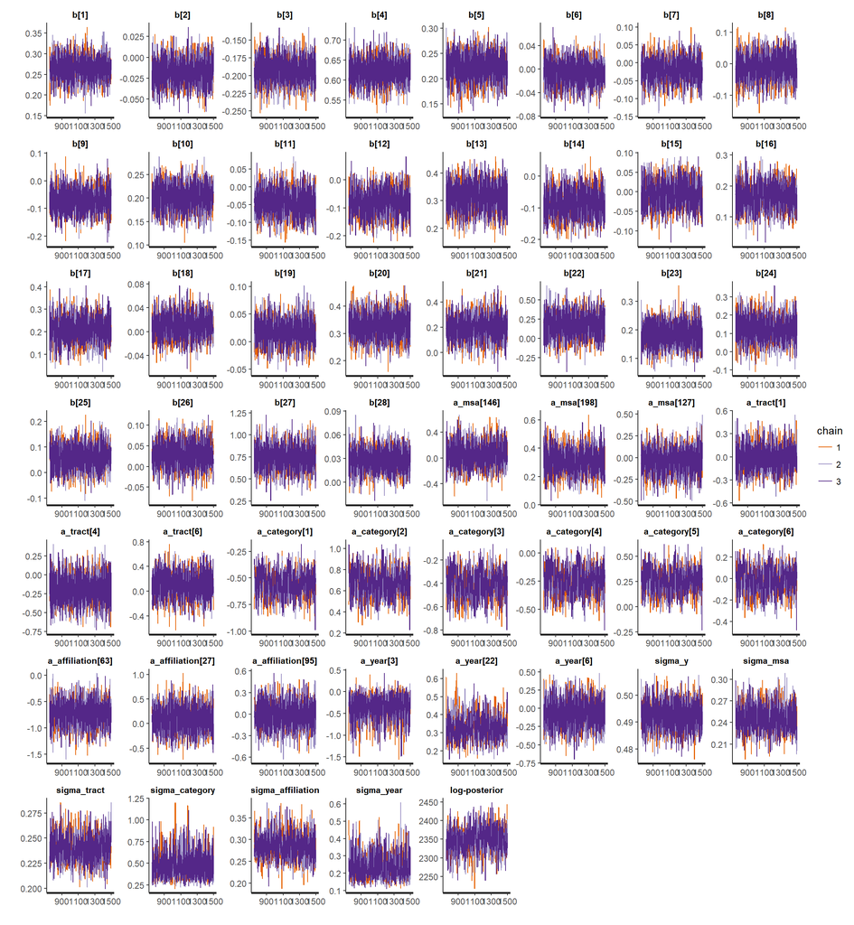

```r
# Sample random intercepts to plot
a_msa_samples <- sample(stan_data_1_3$J_msa, size = 3, replace = FALSE)
a_tract_samples <- sample(stan_data_1_3$J_category, size = 3, replace = FALSE)
a_category_samples <- 1:nlevels(data_train$category)
a_aff_samples <- sample(stan_data_1_3$J_saleaffiliation, size = 3, replace = FALSE)
a_year_samples <- sample(stan_data_1_3$J_year_factor, size = 3, replace = FALSE)


parameters_to_plot = c(paste("b[", 1:stan_data_1_3$K, "]", sep = ""),
                       paste("a_msa[", a_msa_samples, "]", sep = ""),
                       paste("a_tract[", a_tract_samples, "]", sep = ""),
                       paste("a_category[", a_category_samples, "]", sep = ""),
                       paste("a_affiliation[", a_aff_samples, "]", sep = ""),
                       paste("a_year[", a_year_samples, "]", sep = ""),
                       "sigma_y", "sigma_msa", "sigma_tract", "sigma_category",
                       "sigma_affiliation", "sigma_year", "lp__")
stan_trace(stan_1_3, inc_warmup = FALSE, pars = parameters_to_plot)  #Looks good
```

Looks good, The distribution of all parameters that we examined seems stationary. Since we could not manually inspect the distribution of all parameters, let’s look at the maximum value that the RHat statistic takes. This statistic estimates whether the distribution has reached stationarity by comparing within-chain variance with between-chain variance.

```r
#Maximum Rhat
max(summary (stan_1_3)$summary[, "Rhat"])  #Looks good
```

```
## [1] 1.033563
```

For all parameters, these are easily below 1.1, as recommended by Andrew Gelman. Thus, all parameter distributions seem to be stationary. In other words, the parameter estimates seem to be trustworthy.

Finally, let’s inspect the residuals to see if there is any evidence of nonlinearity or of influential points (points which are both far away from where most points are, and which also have large residuals). In order to make it easier to diagnose nonlinearity, I have added a smoother, which should hover around 0 everywhere if there is no nonlinearity present. Let’s start with the model were all continuous variable enter as logs:

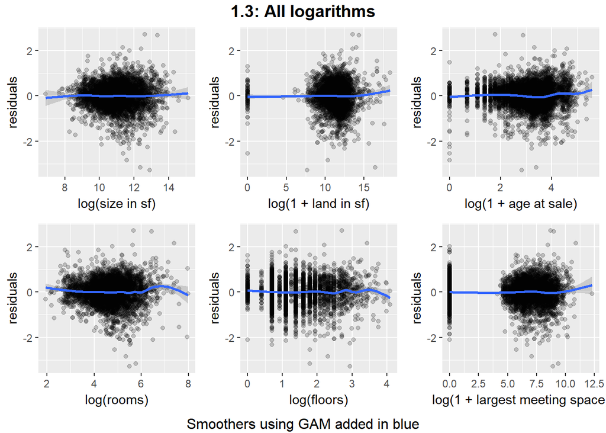

```r
plot_stan_residuals <- function(stan_model, variables, data,
                                 title = NULL,
                                 xlabels = NULL, ylabel = "residuals",
                                 alpha = 0.2, dimensions = NULL){
  # Plots residuals versus features, and adds a smoother. For each observation,
  # the mean residual is used.  In other words, we abstract from the
  # uncertainty of parameter estimates, but this should not be a problem.
  #
  # Args:
  # -----
  #
  # stan_model: Name of the Stan model
  # variables: character vector with names of the variables to plot,
  # data: data frame that holds the original data.  (Not the list with the input
  #     data that is fed into Stan.
  # title: string; optional. Custom title for plots. Default: None, which uses
  #     the model name from the .stan as the title. (Note that this is different
  #     from the name of the name to  which the stand model was assigned in R.
  #     Thus, it is recommended to set a custom title if the same .stan file is
  #     reused to estimate different models.)
  # alpha: numeric between 0 and 1; optional; adjusts transparency to avoid overplotting.
  # dimensions: vector of positive integers of length 2; optional; gives number of rows
  #     and columns for arranging plots.
  # xlabels: character vector; default NULL; labels for x-axes
  # ylabel: character string; default "residuals"; labels for y-axes
  #
  # Returns:
  # -------
  #
  # None (only prints the plots)

    # Extract the residuals from the model
    residuals <- extract(stan_model)$residuals

    # For now, ignore parameter uncertainty and simply compute average
    # residual for for each observation.
    data$residuals_mean <- apply(residuals, 2, mean)

    # Set title to default or custom
    if (is.null(title))
        plot_title <- paste("Model:", stan_model@model_name) else plot_title <- title


    library(ggplot2)
    plot_list = list()  #initialize list to store all the individual plots

    # Initialize counter to keep track of xlabels
    i = 1

    # Create all plots and add them to a list
    for (variable in variables) {
        # Set labels for x-axis to default or custom
        xlabel <- ifelse(is.null(xlabels), variable, xlabels[i])

        # Note that we are using aes_string instead of aes, since we get the
        # variables to plot as strings.
        plot_list[[variable]] <- ggplot(data = data, aes_string(x = variable,
            y = "residuals_mean")) + # coord_trans (x = 'log') + #Doesn't work if variable contains zeros,
        labs(y = ylabel, x = xlabel) + geom_point(alpha = alpha) + geom_smooth()  #Add smoother

        # Increment counter
        i = i + 1
    }

    # Combine all the plots into one. Note that I don't load the ggpubr
    # package since it masks RStan's extract()
    figure <- ggpubr::ggarrange(plotlist = plot_list)  #, labels = variables)
    # Deleted labels because I didn't have the time yet to arrange them
    # properly.

    # Add title
    ggpubr::annotate_figure(figure, top = ggpubr::text_grob(plot_title,
        face = "bold", size = 14),
        bottom = ggpubr::text_grob("Smoothers using GAM added in blue"))
}

# Plot
plot_stan_residuals (stan_1_3,
                     c("log_sizesf", "log1_landsf", "log1_age",
                       "log_rooms", "log_floors", "log1_largestmeetingspace"),
                     xlabels = c ("log(size in sf)", "log(1 + land in sf)",
                                  "log(1 + age at sale)", "log(rooms)",
                                  "log(floors)",
                                  "log(1 + largest meeting space)"
                                  ),
                     title = "1.3: All logarithms",
                     data = data_train)
```

The residual plots show no major problems, but they indicate that the relationships for most of these variables might be slightly more complex than linear on the log scale (constant elasticity on the original scale). However, the residuals do not simply indicate a polynomial relationship but seem to require a more flexible model, such as a General Additive Model. Still, our linear model captures the relationship pretty well, indicated by the fact that the confidence intervals of the smoother do include 0 almost everywhere.

# Interpreting the Coefficients

Let’s now take a look at the effect sizes. The percentages in the tables below tell us the percentiles of the (posterior) distribution of our parameter estimates. E.g., we can say that with 50% probability, the true value lies between 25% and 75%. (Note that this is different from the meaning of a confidence interval in a non-Bayesian context). “sd” gives the standard deviation of this distribution, while “se_mean” tells us how much the uncertainty of our parameter estimates is increased by running only a finite amount of MCMC samples (in this final version, I ran enough samples that it is small enough to be ignored).

Remember that, even though I had to standardize all continuous variables to estimate the model, the effect sizes shown are converted back to the original scale.

Before we take a look at our result, let’s define a function that formats the output. Firstly, it adds the variable names to the coefficient vecotor. Secondly it converts the coefficients off standardize variables back to the original scale, so that we can interpret the effect size.

```r
### Function to pretty print Stan output:
get_stan_coefs <- function(stan_model, stan_data, original_scale = TRUE,
                           y_standardized = FALSE, digits = 3, print = TRUE) {
  # Returns and prints summary of a stan model that was defined using matrix
  # multiplication by converting coefficients to original scale and adding
  # variable names to coefficient names.
  #
  # Args:
  #   stan_model: Stan model objects for which to print coefficients.
  #   stan_data: list, which holds the data used to estimate model, generated by
  #              (or of same format as) make_stan_data().
  #   original_scale: boolean, whether to print coefficients on standardized or
  #               original scale. Default: original scale.
  #   y_standardized: boolean, whether the dependent variable was also
  #               standardized. Only needs to be specified if original_scale = T.
  #               Default: FALSE.
  #   digits: numeric, number of decimals to print for each entry. Default: 3.
  #
  # Returns:
  #   list

  # Select only fixed effects
  parameters_to_print = c(paste("b[", 1:(stan_data[["K"]]), "]", sep = ""))
  # create a data frame of the parameter estimates for the fixed effects
  df <- summary(stan_model, pars = parameters_to_print)$summary

  # append substantive names to parameter estimates
  rownames(df) <- paste("b", colnames(stan_data[["X"]]), sep = "_")

  # If specified, convert parameters to original scale (Remember we divided by 2 standard deviations)
  if (original_scale == TRUE) {
    if (y_standardized == TRUE)
      stop("Not implemented yet.")
    for (parameter in 1:nrow(df)) {
      # If the saved standard deviation is NA, the variable was not standardized because it is not continuous.
      # Therefore, go on to next parameter.
      if (is.na(stan_data$sd_x[parameter]))
        next else {
          # Otherwise, divide the first 8 elements of each row (that's what contains coefficients) by twice the standard deviation (remember
          # that's how we standardized variables)
          df[parameter, 1:8] <- df[parameter, 1:8]/(2 * stan_data$sd_x[parameter])
        }
    }
  }

  # Select intercept plus variance parameters for error and random effects
  re_to_print <- rownames(summary(stan_model)$summary)[startsWith(rownames(summary(stan_model)$summary), "sigma")]
  df_2 <- summary(stan_model, pars = c("intercept", re_to_print))$summary

  # Concatenate both data frames
  df_combined <- rbind(df, df_2)

  # Print (if specified) and return
  if (print == TRUE) print(round(df_combined, digits = digits))
  return(list(b = df[, "mean"],
              intercept = summary(stan_model, pars = "intercept")$summary[, "mean"],
              all = summary(stan_model)$summary[, "mean"]))
}

# Print model (parameter estimates for standardized predictors are converted back to original scale)
stan_coefs_1_3_orig_scale <- get_stan_coefs(stan_1_3, stan_data_1_3)
```

```
##                              mean se_mean    sd   2.5%    25%    50%
## b_log_sizesf                0.144   0.000 0.015  0.113  0.134  0.144
## b_log1_landsf              -0.005   0.000 0.005 -0.014 -0.008 -0.005
## b_log1_age                 -0.112   0.000 0.010 -0.132 -0.118 -0.112
## b_log_rooms                 0.446   0.000 0.022  0.403  0.431  0.446
## b_log_floors                0.170   0.000 0.020  0.129  0.156  0.169
## b_log1_largestmeetingspace -0.001   0.000 0.003 -0.007 -0.003 -0.001
## b_operationFranchise       -0.021   0.001 0.032 -0.086 -0.042 -0.021
## b_operationIndependent     -0.011   0.001 0.040 -0.090 -0.038 -0.012
## b_selfrun                  -0.071   0.001 0.041 -0.149 -0.099 -0.071
## b_portfolio                 0.202   0.001 0.026  0.151  0.185  0.202
## b_multiproperty            -0.043   0.001 0.036 -0.114 -0.068 -0.043
## b_locationInterstate       -0.081   0.001 0.045 -0.169 -0.111 -0.081
## b_locationResort            0.311   0.001 0.050  0.213  0.277  0.312
## b_locationSmallMetro/Town  -0.088   0.001 0.042 -0.168 -0.117 -0.087
## b_locationSuburban         -0.005   0.001 0.033 -0.073 -0.026 -0.004
## b_locationUrban             0.166   0.001 0.040  0.085  0.139  0.167
## b_cbd                       0.212   0.001 0.054  0.105  0.176  0.211
## b_indoorcorridors           0.010   0.000 0.020 -0.028 -0.003  0.010
## b_restaurant                0.018   0.000 0.023 -0.027  0.002  0.017
## b_convention                0.330   0.001 0.047  0.237  0.298  0.331
## b_conference                0.195   0.002 0.093  0.014  0.132  0.195
## b_ski                       0.179   0.003 0.155 -0.123  0.075  0.177
## b_spa                       0.185   0.001 0.042  0.104  0.156  0.185
## b_golf                      0.126   0.001 0.070 -0.010  0.078  0.126
## b_boutique                  0.061   0.001 0.046 -0.030  0.029  0.062
## b_allsuites                 0.028   0.001 0.031 -0.031  0.007  0.028
## b_casino                    0.747   0.003 0.134  0.490  0.656  0.751
## b_quarter                   0.013   0.000 0.007  0.000  0.008  0.013
## intercept                  15.518   0.004 0.102 15.315 15.450 15.515
## sigma_y                     0.492   0.000 0.005  0.483  0.489  0.492
## sigma_msa                   0.246   0.001 0.017  0.214  0.233  0.245
## sigma_tract                 0.240   0.001 0.013  0.217  0.231  0.240
## sigma_category              0.473   0.005 0.144  0.275  0.371  0.443
## sigma_affiliation           0.285   0.001 0.028  0.235  0.266  0.284
## sigma_year                  0.240   0.003 0.068  0.139  0.190  0.229
##                               75%  97.5%    n_eff  Rhat
## b_log_sizesf                0.154  0.173 2250.000 1.000
## b_log1_landsf              -0.002  0.004 2250.000 1.000
## b_log1_age                 -0.105 -0.091 2250.000 1.001
```

[output cut: 17 more lines]

```
## b_conference                0.257  0.375 2250.000 1.000
## b_ski                       0.281  0.479 2250.000 1.000
## b_spa                       0.215  0.262 2250.000 0.999
## b_golf                      0.173  0.265 2250.000 1.000
## b_boutique                  0.092  0.152 2250.000 0.999
## b_allsuites                 0.050  0.089 1925.034 1.001
## b_casino                    0.833  1.021 2250.000 1.000
## b_quarter                   0.017  0.026 2250.000 0.999
## intercept                  15.584 15.719  540.202 1.002
## sigma_y                     0.495  0.502 2250.000 1.000
## sigma_msa                   0.257  0.281  778.407 1.000
## sigma_tract                 0.249  0.266  585.323 1.001
## sigma_category              0.544  0.831  804.305 1.002
## sigma_affiliation           0.303  0.343  694.279 1.005
## sigma_year                  0.278  0.401  552.573 1.007
```

For comparison, let’s also estimate a non-Bayesian multilevel model with maximum likelihood (which is less sensitive to errors):

```r
# Frequentist (maximum likelihood) estimate of hierarchical model for comparison====
library (lme4)
lmer_1_3 <- lmer (log_saleprice ~ log_sizesf + log1_landsf +
                    log1_age + log_rooms + log_floors + log1_largestmeetingspace +
                    operation + selfrun + portfolio + multiproperty + location  +
                    cbd + indoorcorridors + restaurant + convention +
                    conference + ski + spa + golf + boutique +
                    allsuites + casino + quarter +
                    (1 |msa) + (1 | tract) + (1|category) + (1|year),
                  data=data_train)
summary(lmer_1_3)
```

```
## Linear mixed model fit by REML ['lmerMod']
## Formula:
## log_saleprice ~ log_sizesf + log1_landsf + log1_age + log_rooms +
##     log_floors + log1_largestmeetingspace + operation + selfrun +
##     portfolio + multiproperty + location + cbd + indoorcorridors +
##     restaurant + convention + conference + ski + spa + golf +
##     boutique + allsuites + casino + quarter + (1 | msa) + (1 |
##     tract) + (1 | category) + (1 | year)
##    Data: data_train
##
## REML criterion at convergence: 10649
##
## Scaled residuals:
##     Min      1Q  Median      3Q     Max
## -7.8987 -0.5155  0.0352  0.5773  5.2261
##
## Random effects:
##  Groups   Name        Variance Std.Dev.
##  tract    (Intercept) 0.06110  0.2472
##  msa      (Intercept) 0.06560  0.2561
##  year     (Intercept) 0.04062  0.2015
##  category (Intercept) 0.24415  0.4941
##  Residual             0.26645  0.5162
## Number of obs: 6292, groups:  tract, 629; msa, 342; year, 22; category, 6
##
## Fixed effects:
##                            Estimate Std. Error t value
## (Intercept)              12.0665037  0.2574879   46.86
## log_sizesf                0.1533948  0.0159578    9.61
## log1_landsf              -0.0033351  0.0048842   -0.68
## log1_age                 -0.1526088  0.0099463  -15.34
## log_rooms                 0.4501563  0.0217702   20.68
## log_floors                0.1776952  0.0197214    9.01
## log1_largestmeetingspace -0.0004286  0.0029066   -0.15
## operationFranchise       -0.0455177  0.0300028   -1.52
## operationIndependent     -0.1498112  0.0318614   -4.70
## selfrun                  -0.0900542  0.0417239   -2.16
## portfolio                 0.2874244  0.0258074   11.14
## multiproperty            -0.0198128  0.0370190   -0.54
## locationInterstate       -0.0853433  0.0476046   -1.79
## locationResort            0.3160299  0.0514726    6.14
## locationSmall Metro/Town -0.0787958  0.0456904   -1.72
## locationSuburban          0.0061427  0.0358915    0.17
## locationUrban             0.1799432  0.0431328    4.17
## cbd                       0.2255123  0.0562177    4.01
## indoorcorridors           0.0127226  0.0203788    0.62
## restaurant               -0.0188575  0.0208276   -0.91
## convention                0.3038749  0.0469744    6.47
## conference                0.1806618  0.0921414    1.96
## ski                       0.2464122  0.1671268    1.47
## spa                       0.1617202  0.0421834    3.83
## golf                      0.1537358  0.0726770    2.12
## boutique                  0.0446574  0.0414006    1.08
## allsuites                 0.0025018  0.0218801    0.11
## casino                    0.7369279  0.1409814    5.23
## quarter                   0.0105468  0.0071386    1.48
```

```
##
## Correlation matrix not shown by default, as p = 29 > 12.
## Use print(x, correlation=TRUE)  or
##   vcov(x)     if you need it
```

Again, the results look similar.

# Shrinkage

The central advantage of a hierarchical model is that it performs an adaptive shrinkage for group-level parameters (in our case the intercepts for the different MSAs, tracts, hotel categories and affiliations, and years): It avoids overfitting these parameter estimates to the particular data we happen to observe by shrinking parameter estimates towards zero, and it takes into account that we have greater uncertainty about groups for which the sample size is lower or for which the variance between different groups is higher. In the extreme case, as the number of observations for a particular group goes towards infinity, virtually no shrinkage is performed because we do have enough information to estimate the effect precisely. Conversely, if we only have one observation for a particular group, our best estimate is going to be close to zero. (For example, if we only have one observation for a particular city, our best estimate for the intercept of that city is close to 0.) The reason that the individual group effects are shrunken towards zero and not to some group average is that the effect of the average group (MSA, year, etc.) is by definition zero, because our model contains an intercept that absorbs all constants.

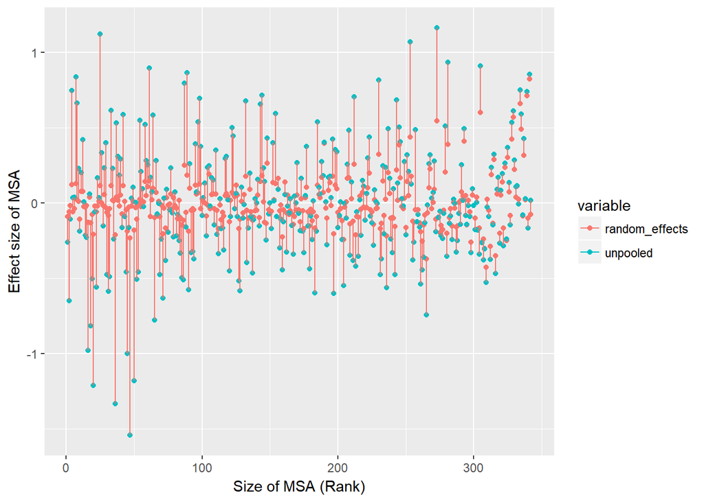

```r
### Plot shrinkage====
## Start with MSA
# First create a data frame with columns for both the random effecs and the
# unpooled estimates, as well as the number of samples for each group (for
# sorting).
msa_estimates <- data.frame(matrix(nrow = nlevels(data_train$msa), ncol = 4))
names(msa_estimates) <- c("random_effects", "unpooled",
                          "sample_size", "rank")
rownames(msa_estimates) <- levels(data_train$msa)

# Compute the mean estimate for the random intercept for each MSA
msa_estimates[, 1] <- apply(extract(stan_1_3)$a_msa, 2, mean)

# Add unpooled intercepts from OLS
# Estimate OLS without intercept with the variable of interest 1st (if multiple
# factors are included, so that the 1st group will not be dropped in order to
# avoid collinearity.)
ols_msa <- lm(log_saleprice ~ -1 + msa + log_sizesf + log1_landsf +
             log1_age + log_rooms + log_floors +
             operation + selfrun + portfolio + multiproperty + location  +
             cbd + indoorcorridors + restaurant + convention +
             conference + ski + spa + golf + boutique +
             allsuites + casino + quarter + year +
             category + year, data = data_train)

# Add coefficients to data frame
msa_estimates[, 2] <- coef(ols_msa)[1:nrow(msa_estimates)]

# Subtract the mean from unpooled estimates since we did not include an intercept
msa_estimates[, 2] <- msa_estimates[, 2] - mean(msa_estimates[, 2])

## Check that we selected the right coefficients. First check that both the 1st and
## last coefficients we selected belong to the variable of interest
selected_coefficients <- names(coef(ols_msa))[1:nrow(msa_estimates)]
if (!all(startsWith(selected_coefficients, "msa"))) {
    stop("some of the selected coefficients for the pooled data belong to other
        variables.")
}

# Make sure that the 1st coefficient not selected belongs to a different variable
next_coefficient <- names(coef(ols_msa))[nrow(msa_estimates) + 1]
if (startsWith(next_coefficient, "msa")) {
    stop("not all coefficient selected")
}

# Number of samples for each group
msa_estimates[, 3] <- as.vector(table(data_train$msa))

# Sort by number of samples
msa_estimates <- msa_estimates[order(msa_estimates$sample_size), ]

# rank for each group
msa_estimates[, 4] <- 1:nrow(msa_estimates)

# Drop sample size (to make plotting easier)====
msa_estimates <- msa_estimates[, c(-3)]

# Reshape data frame from a wide to long format for ggplot
library(reshape2)
msa_estimates_long <- melt(data = msa_estimates, id.vars = "rank")

# Plot data Shrinkage
library(ggplot2)
ggplot(msa_estimates_long, aes(y = value, x = rank, color = variable,
                               group = rank)) +
      geom_point() + geom_line() + scale_x_continuous(
        name = "Size of MSA (Rank)") +
      scale_y_continuous(name = "Effect size of MSA")
```

```r
ggtitle("Shrinkage")
```

```
## $title
## [1] "Shrinkage"
##
## $subtitle
## NULL
##
## attr(,"class")
## [1] "labels"
```

The above plot shows the essence of a hierarchical model: For MSAs with a small sample size (left) there is a large difference between the OLS estimates(green) and the random effects estimates of the hierarchical model (red), because the latter pulls the extreme estimates back towards zero (the red vertical lines are long). As we moved to the right, the sample size from each MSA increases; as a result, their coefficients can be estimated more precisely, and thus the hierarchical model shrinks these coefficients to an increasingly small extent (the red vertical lines get shorter). Consequently, the estimates of the hierarchical model become larger in absolute value. In order to better show this last point, let us only plot the estimates from the hierarchical model in a separate graph:

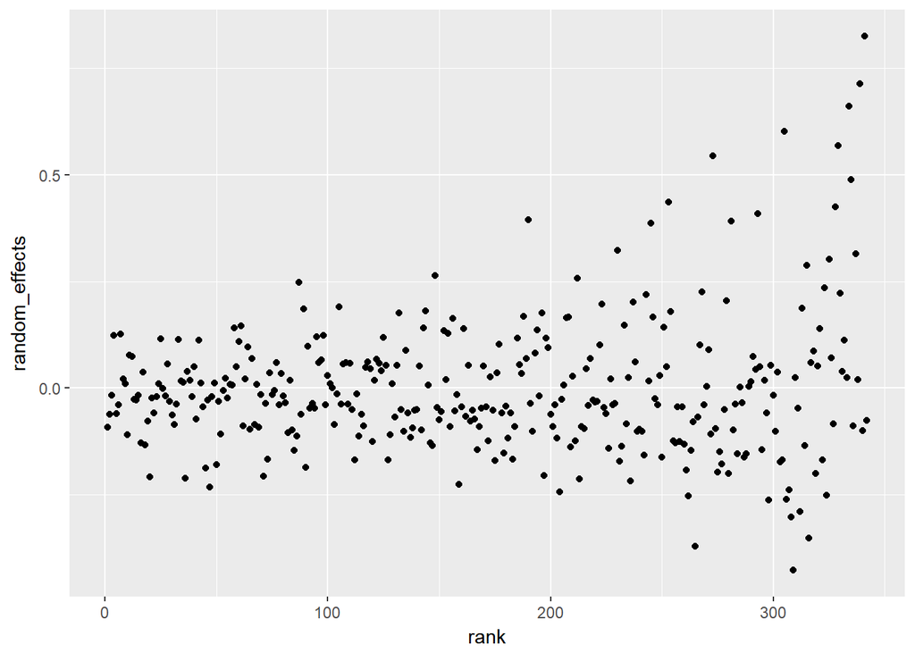

```r
#Plot only the random effect estimates
ggplot(msa_estimates, aes(y = random_effects, x = rank)) + geom_point()
```

(Note that, for MSAs with the highest sample sizes (right), the majority of the extreme values is positive rather than negative. This is to be expected, because MSAs with the highest population tend to have the highest property prices, and due to their high population there will also be a larger number of hotels, leading to a higher sample size.)

# Interpreting the random effects

Now let’s take a look at the random effects, to see where the biggest source of variation lies.

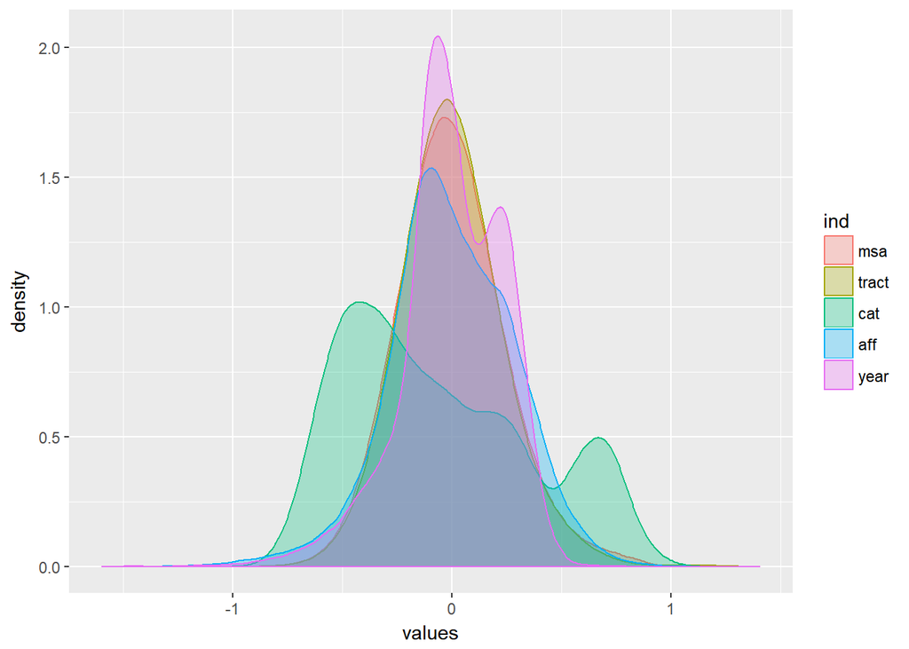

```r
# Initialize empty list to hold estimates for the random intercept for
# all groups (Will be converted to data frame once we know the needed
# dimension)====
re_list <- list()
for (random_intercept in c("msa", "tract", "cat", "op", "aff", "year")) {
    # select all the estimates for the random intercepts for all groups
    model_parameters <- as.data.frame(stan_1_3)
    # For each grouping variable, combine all estimates in a vector
    re_list[[random_intercept]] <- unlist(
        model_parameters[, startsWith(names(model_parameters),
        paste("a", random_intercept, sep = "_"))])
}

# Find the length of the longest vector of random intercepts, as well
# as the the number of random intercepts/grouping variables
maximum_length <- 0
n_re <- 0
for (re_vector in re_list) {
    if (length(re_vector) > maximum_length)
        maximum_length <- length(re_vector)
    n_re <- n_re + 1
}

# Combine all vectors of random intercepts in a data frame
re_frame <- data.frame(matrix(nrow = maximum_length, ncol = n_re))
column_counter <- 1  #counter to keep track of columns
for (re_vector in re_list) {
    re_frame[1:length(re_vector), column_counter] <- re_vector
    names(re_frame)[column_counter] <- names(re_list)[column_counter]
    column_counter = column_counter + 1
}

# Create density plot====
re_stack <- stack(re_frame)
ggplot(re_stack, aes(x = values)) + geom_density(aes(group = ind, colour = ind,
    fill = ind), alpha = 0.3)
```

# Measuring accuracy

Evaluate fit of predictions from generated quantities.

```r
# Compute mean prediction for each observation in test set
log_y_pred <- apply(
                extract(stan_1_3)$y_pred_test[501:1500, ],
                2, mean)
y_pred <- exp(log_y_pred)

# Residuals on log scale
resids_log_stan_1_3 <- data_test$log_saleprice - log_y_pred
# Residuals on original scale
resids_stan_1_3 <- data_test$saleprice - y_pred

# Root mean squared log error
rmsle_stan_1_3 <- sqrt(mean((resids_log_stan_1_3)**2))
rmsle_stan_1_3
```

```
## [1] 0.6727645
```

```r
# Root mean squared error
rmse_stan_1_3 <- sqrt(mean((resids_stan_1_3)**2))
rmse_stan_1_3
```

```
## [1] 104108401
```

```r
rSquared(data_test$log_saleprice, resids_log_stan_1_3) # 0.69
```

```
##          [,1]
## [1,] 0.698453
```

```r
rSquared(data_test$saleprice, resids_stan_1_3) # -2.06
```

```
##          [,1]
## [1,] -2.23263
```

```r
# data_train_ols <- data_train
# data_test_ols <- data_test
# # Add 2017 as an extra level of year_factor to training set
# levels(data_train_ols$year_factor) <- c(levels(data_train_ols$year_factor),
#                                         "2017")
#
# # Modify test data: Set year to most recent year from training set
# data_test_ols <- data_test
# levels(data_test_ols$year_factor) <- levels(data_train_ols$year_factor)
# data_test_ols[, "year"] <- "2016"
# # data_test$year_factor <- as.factor(data_test$year)
#


# Pooled estimate (OLS without intercepts for large categories (MSA, tract,
# sale affiliation)
ols_up <- lm(log_saleprice ~ log_sizesf + log1_landsf +
              log1_age + log_rooms + log_floors + log1_largestmeetingspace +
              operation + selfrun + portfolio + multiproperty + location  +
              cbd + indoorcorridors + restaurant + convention + conference +
              ski + spa + golf + boutique + allsuites + casino +
              quarter + msa + tract + category + saleaffiliation + year_factor,
              data = data_train)
# summary(ols_up) # Uncommented bcbecause of long printout

# Unpooled (OLS with intercept for all categories included in hierarchical model)
ols_p <- lm(log_saleprice ~ log_sizesf + log1_landsf +
              log1_age + log_rooms + log_floors + log1_largestmeetingspace +
              operation + selfrun + portfolio + multiproperty + location  +
              cbd + indoorcorridors + restaurant + convention + conference +
              ski + spa + golf + boutique + allsuites + casino +
              quarter + category + year_factor,
              data = data_train)
summary(ols_p)
```

```
##
## Call:
## lm(formula = log_saleprice ~ log_sizesf + log1_landsf + log1_age +
##     log_rooms + log_floors + log1_largestmeetingspace + operation +
##     selfrun + portfolio + multiproperty + location + cbd + indoorcorridors +
##     restaurant + convention + conference + ski + spa + golf +
##     boutique + allsuites + casino + quarter + category + year_factor,
##     data = data_train)
##
## Residuals:
##     Min      1Q  Median      3Q     Max
## -4.8148 -0.3749  0.0000  0.3924  3.2668
##
## Coefficients:
##                               Estimate Std. Error t value Pr(>|t|)
## (Intercept)                  13.272986   0.661388  20.068  < 2e-16 ***
## log_sizesf                    0.081343   0.018553   4.384 1.18e-05 ***
## log1_landsf                  -0.028812   0.005553  -5.189 2.18e-07 ***
## log1_age                     -0.122574   0.011400 -10.752  < 2e-16 ***
## log_rooms                     0.466999   0.025086  18.616  < 2e-16 ***
## log_floors                    0.290463   0.021794  13.328  < 2e-16 ***
## log1_largestmeetingspace     -0.013108   0.003347  -3.916 9.09e-05 ***
## operationFranchise           -0.154627   0.035279  -4.383 1.19e-05 ***
## operationIndependent         -0.204355   0.037370  -5.468 4.72e-08 ***
## selfrun                      -0.096237   0.049248  -1.954  0.05073 .
## portfolio                     0.257323   0.029999   8.578  < 2e-16 ***
## multiproperty                 0.026818   0.042744   0.627  0.53041
## locationInterstate           -0.207075   0.042784  -4.840 1.33e-06 ***
## locationResort                0.225054   0.042217   5.331 1.01e-07 ***
## locationSmall Metro/Town     -0.197184   0.038201  -5.162 2.52e-07 ***
## locationSuburban             -0.049328   0.032789  -1.504  0.13253
## locationUrban                 0.315779   0.041145   7.675 1.91e-14 ***
## cbd                          -0.040538   0.035464  -1.143  0.25304
## indoorcorridors              -0.021039   0.023339  -0.901  0.36738
## restaurant                    0.042352   0.024500   1.729  0.08393 .
## convention                    0.280010   0.055604   5.036 4.89e-07 ***
## conference                    0.231348   0.107647   2.149  0.03166 *
## ski                          -0.101703   0.187785  -0.542  0.58812
## spa                           0.272220   0.049281   5.524 3.45e-08 ***
## golf                          0.135568   0.084207   1.610  0.10746
```

[output cut: 21 more lines]

```
## year_factor2008              -0.664156   0.638757  -1.040  0.29849
## year_factor2009              -0.914512   0.639281  -1.431  0.15261
## year_factor2010              -0.957107   0.638887  -1.498  0.13416
## year_factor2011              -0.963217   0.638650  -1.508  0.13155
## year_factor2012              -0.962256   0.638589  -1.507  0.13190
## year_factor2013              -0.880600   0.638804  -1.379  0.16809
## year_factor2014              -0.750672   0.699235  -1.074  0.28306
## year_factor2015              -0.646343   0.638648  -1.012  0.31155
## year_factor2016              -0.513048   0.639021  -0.803  0.42208
## ---
## Signif. codes:  0 '***' 0.001 '**' 0.01 '*' 0.05 '.' 0.1 ' ' 1
##
## Residual standard error: 0.6368 on 6237 degrees of freedom
## Multiple R-squared:  0.7224, Adjusted R-squared:   0.72
## F-statistic: 300.6 on 54 and 6237 DF,  p-value: < 2.2e-16
```

```r
## Predictions
## ===========

# For pooled model
# ---------------
log_y_ols_up <- predict(ols_up, data_test)
log_y_ols_p <- predict(ols_p, data_test)

# Predicted value on original scale
y_ols_p <- exp(log_y_ols_p)

# Residuals on log scale
resids_log_ols_p <- data_test$log_saleprice - log_y_ols_p
# Residuals on original scale
resids_ols_p <- data_test$saleprice - y_ols_p

# Root mean squared log error
rmsle_ols_p <- sqrt(mean((resids_log_ols_p)**2))
rmsle_ols_p # 0.58
```

```
## [1] 0.5775646
```

```r
# Root mean squared error
rmse_ols_p <- sqrt(mean((resids_ols_p)**2))
rmse_ols_p
```

```
## [1] 31640134
```

```r
# R_2
rSquared(data_test$log_saleprice, resids_log_ols_p) # 0.78
```

```
##          [,1]
## [1,] 0.777756
```

```r
rSquared(data_test$saleprice, resids_ols_p) # 0.69
```

```
##           [,1]
## [1,] 0.7014198
```

```r
# For UN-pooled model
# ------------------
# Predicted value on original scale
y_ols_up <- exp(log_y_ols_up)

# Residuals on log scale
resids_log_ols_up <- data_test$log_saleprice - log_y_ols_up
# Residuals on original scale
resids_ols_up <- data_test$saleprice - y_ols_up

# Root mean squared log error
rmsle_ols_up <- sqrt(mean((resids_log_ols_up)**2))
rmsle_ols_up # 0.52
```

```
## [1] 0.5159185
```

```r
# Root mean squared error
rmse_ols_up <- sqrt(mean((resids_ols_up)**2))
rmse_ols_up
```

```
## [1] 35651174
```

```r
# R_2
rSquared(data_test$log_saleprice, resids_log_ols_up) # 0.82
```

```
##           [,1]
## [1,] 0.8226664
```

```r
rSquared(data_test$saleprice, resids_ols_up) # 0.62
```

```
##           [,1]
## [1,] 0.6209189
```

```r
# Compare means between all models, as well as original data
# ==========================================================

# Original scale
mean(data_test$saleprice) / 1E6
```

```
## [1] 19.68855
```

```r
mean(y_pred) / 1E6
```

```
## [1] 34.07257
```

```r
mean(y_ols_p) /1E6
```

```
## [1] 14.40004
```

```r
mean(y_ols_up) / 1E6
```

```
## [1] 15.51626
```

```r
# Log scale
mean(data_test$log_saleprice)
```

```
## [1] 15.75788
```

```r
mean(log_y_pred)
```

```
## [1] 15.65853
```

```r
mean(log_y_ols_p)
```

```
## [1] 15.74608
```

```r
mean(log_y_ols_up)
```

```
## [1] 15.70178
```

```r
# We see thatwhen we convert the prediction to the original scale, the
# hierarchical model has a extreme upwards bias, whereas the other models have a
# smaller downward bias.  This is strange.
```